# COMFAMA

Luis Barrios

2022-05-11

# Introducción:

## Total titulares, total familiares y gestiones realizadas por sandra

- Total personas: 224
- Total titulares: 127
- Total familiares: 97
- Total gestionados (color celeste): 127

Se han gestionado a los titulares, mas no a los familiares.

# Desarrollo:

## Numero de personas que desean beca y no son titulares

- Desean aplicar a la beca: 50
- Desean aplicar a la beca y han sido contactados: 42
- Desean aplicar a la beca y no son titulares: 8

| Parentesco | n |
| --- | --- |
| Titular | 42 |
| Hijo | 5 |
| Cónyuge - Compañera | 2 |
| Beneficiario | 1 |

### ¿Cuantos estan contactados?

Dado que los contactados solo son los de color azul y según la data son todos los “Titulares”, por lo tanto tenemos 42 personas que desean una beca y han sido contactados.

### ¿Cuantos desean aplicar a beca?

Son 8 los que desean aplicar a la beca y no son titulares.

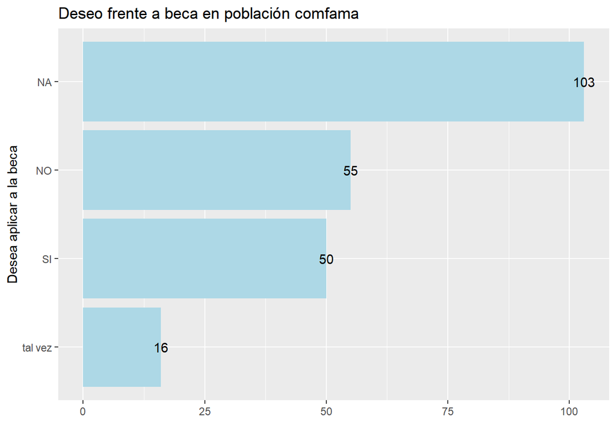

| ¿Desea aplicar a la beca? | Parentesco | n | porcentaje_total |
| --- | --- | --- | --- |
| NO | Titular | 34 | 15.2 |
| NO | Cónyuge - Compañera | 8 | 3.6 |
| NO | Padre | 5 | 2.2 |
| NO | Madre | 4 | 1.8 |
| NO | Hijo | 3 | 1.3 |
| NO | Hijastro | 1 | 0.4 |
| SI | Titular | 42 | 18.8 |
| SI | Hijo | 5 | 2.2 |
| SI | Cónyuge - Compañera | 2 | 0.9 |
| SI | Beneficiario | 1 | 0.4 |
| tal vez | Titular | 10 | 4.5 |
| tal vez | Hijo | 3 | 1.3 |
| tal vez | Cónyuge - Compañera | 2 | 0.9 |
| tal vez | Madre | 1 | 0.4 |
| NA | Titular | 41 | 18.3 |
| NA | Cónyuge - Compañera | 21 | 9.4 |
| NA | Madre | 18 | 8.0 |
| NA | Padre | 12 | 5.4 |
| NA | Hijo | 10 | 4.5 |
| NA | Hermano | 1 | 0.4 |

# Número de titulares beneficiados

En total son 127 titulares, de los cuales 42 desean aplicar a la beca y han sido contactados.

### ¿ El total de beneficiarios a cuantos titulares corresponden?

Del total de personas por parentesco una aparece como beneficiario.

| Parentesco | n |
| --- | --- |
| Titular | 127 |
| Cónyuge - Compañera | 33 |
| Madre | 23 |
| Hijo | 21 |
| Padre | 17 |
| Beneficiario | 1 |
| Hermano | 1 |
| Hijastro | 1 |

# Conclusiones:

1. De las **224** personas en la data, **127** han sido gestionados y a su vez son titulares, de estos 127 titulares **42** desean aplicar a la beca.
2. El **56.7%** de la población total ha sido gestionado (es titular), solo el **33%** de los gestionados desea aplicar a la beca.
3. El **22%** del total de personas desea aplicar a la beca
4. El **3.6%** del total de personas desea aplicar a la beca y son familiares del titular, siendo el **62%** de estos familiares, hijos.
5. El **7.1%** del total de personas aún estan indecisos de si aplicar a la beca o no.
6. El **61.8%** de los que no desean aplicar a la beca son titulares.
7. El **84%** de los que si desean aplicar a la beca son titulares.
8. El **62.5%** de los que tal vez accedan a la beca son titulares.
9. El **39.8%** de los que no han respondido al beneficio de la beca son titulares.

# Referencias:

1. https://docs.google.com/spreadsheets/d/1kxD4Q7s5poNu00depO-ImxbRf7DzPTsJHI_iet827VE/edit?usp=sharing